# Rejection data: Exploring the raw data

## 1. Country Overview

In this section we take a look at the Country X Instrument data availability -this is the basic unit of analysis. We have a pool of 34 countries but since some countries have multiple instruments this yields 57 possible “Country X Instrument” combinations. This number somewhat exaggerates the pool of units available since some “Country X Instrument” combinations while coded as “Complete” do not actually have any data. “Greece Agenda initiative” is an example since the instrument has not been implemented yet (we should think of a different label for these countries).

The table below lists all our current status of categories for the data availability.

#### Table: 1.1 Data overview

**CLICK TO SEE RESULTS**

| Results | n | prop |
| --- | --- | --- |
| Complete | 24 | 42.1 |
| Complete-No cases | 2 | 3.5 |
| No information | 21 | 36.8 |
| Ongoing | 4 | 7.0 |
| Partially complete | 5 | 8.8 |
| Partially complete -No cases | 1 | 1.8 |

In the tables below we look at the “Country X Instrument” instances for all the main categories. We bgin with the data table of cases that could not be collected for the Reason stated in the column by that name.

#### Table: 1.2 Country data that could not be collected

**CLICK TO SEE RESULTS**

| # | Country | Instrument | Reason |
| --- | --- | --- | --- |
| 1 | Albania | Agenda initiative | no institution in charge of admissibility test |
| 2 | Andorra | Agenda initiative | Website/Translation problems |
| 3 | Armenia | Agenda initiative | Website/Translation problems |
| 4 | Armenia | Proactive initiative | NA |
| 5 | Bulgaria | Agenda initiative | too many institutions in charge |
| 6 | Denmark | Agenda initiative | information is not public |
| 7 | Latvia | Agenda initiative | information is not public |
| 8 | Liechtenstein | Rejective initiative | information is not public |
| 9 | Moldova | Proactive initiative | Website/Translation problems |
| 10 | Montenegro | Agenda initiative | no institution in charge of admissibility test |
| 11 | Montenegro | Proactive initiative | no institution in charge of admissibility test |
| 12 | North Macedonia | Agenda initiative | Website/Translation problems |
| 13 | North Macedonia | Proactive initiative | information is not public |
| 14 | Poland | Agenda initiative | Website/Translation problems |
| 15 | Poland | Proactive initiative | no institution in charge of admissibility test |
| 16 | Russia | Agenda initiative | information is not public |
| 17 | Russia | Proactive initiative | information is not public |
| 18 | Serbia | Agenda initiative | no institution in charge of admissibility test |
| 19 | Serbia | Proactive initiative | Website/Translation problems |
| 20 | Slovakia | Agenda initiative | too many institutions in charge |
| 21 | Ukraine | Agenda initiative | information is not public |

#### Table: 1.3 Country data that is “ongoing”

**CLICK TO SEE RESULTS**

| # | Country | Instrument |
| --- | --- | --- |
| 1 | Finland | Agenda initiative |
| 2 | Georgia | Agenda initiative |
| 3 | Georgia | Proactive initiative |
| 4 | Hungary | Proactive initiative |

In the table above there are 2 countries in which the data is still being either checked (Finland) or ongoing due to its large volume (Hungary). These two cases will be included while it is likely the Georgia will be excluded as a “no information” case

#### Table: 1.4 Country data thqta could be “partially” collected

**CLICK TO SEE RESULTS**

| # | Country | Instrument | Reason | n |
| --- | --- | --- | --- | --- |
| 1 | Italy | Rejective initiative | No information on formal inadmissible | 91 |
| 2 | Latvia | Proactive initiative | Only from 2012 on | 34 |
| 3 | Portugal | Agenda initiative | (but no information on the initiatives that did not get enough signatures) | 11 |
| 4 | Portugal | Proactive initiative | (but no information on the initiatives that did not get enough signatures) | 4 |
| 5 | Ukraine | Proactive initiative | (no data from before 1999 and after 2014) | 26 |

The table above shows countries for which partial data has been collected. It also gives an idea of the number of observations for each case. For the analysis in the sections below, I think we can include Latvia among the complete cases.

#### Table: 1.5 Complete cases (country data that could be collected)

**CLICK TO SEE RESULTS**

| # | Country | Instrument | n |
| --- | --- | --- | --- |
| 1 | Switzerland | Proactive initiative | 273 |
| 2 | Italy | Agenda initiative | 231 |
| 3 | Estonia | Agenda initiative | 154 |
| 4 | Spain | Agenda initiative | 118 |
| 5 | Switzerland | Rejective initiative | 107 |
| 6 | Slovenia | Rejective initiative | 95 |
| 7 | San Marino | Proactive initiative | 48 |
| 8 | Slovenia | Agenda initiative | 47 |
| 9 | Austria | Agenda initiative | 36 |
| 10 | Netherlands | Agenda initiative | 33 |
| 11 | Lithuania | Proactive initiative | 31 |
| 12 | San Marino | Rejective initiative | 31 |
| 13 | Bulgaria | Proactive initiative | 23 |
| 14 | Lithuania | Agenda initiative | 21 |
| 15 | Liechtenstein | Proactive initiative | 18 |
| 16 | Croatia | Proactive initiative | 15 |
| 17 | Romania | Agenda initiative | 11 |
| 18 | Slovakia | Proactive initiative | 7 |
| 19 | Albania | Rejective initiative | 2 |
| 20 | Liechtenstein | Agenda initiative | 2 |
| 21 | Albania | Proactive initiative | 1 |
| 22 | Azerbaijan | Agenda initiative | 1 |
| 23 | Luxembourg | Rejective initiative | 1 |
| 24 | Malta | Rejective initiative | 1 |

The table above is the current complete list of cases organised in descending order by the number of observations.

## 2. Exploring the Complete cases

There is still an issue however. Some country combinations have an extremely low count (e.g. 1 observation/evet). This would be very problematic for calculating a rate. I think a pragmatic solution for now would be to apply an inclusion criterion of at least more than 2 observations to be included in the case selection (probably I’d go up to around 5, but the exact value can be assessed later).

Applying the `> 2` criterion removes the following 6 cases where there is insufficient instances to draw any conclusions. Note that these cases could be looked at more systematically on an individual basis.

1. Albania proactive initiative
2. Albania rejective initiative
3. Azerbaijan agenda initiative
4. Liechtenstein agenda initiative
5. Luxembourg rejective initiative
6. Malta rejective initiative

After applying the `> 2` inclusion criterion, there are 19 complete cases, which vary quite markedly in their distribution of observations as shown below.

#### Figure: 2.1 Frequencies for Complete cases

**CLICK TO SEE RESULTS**

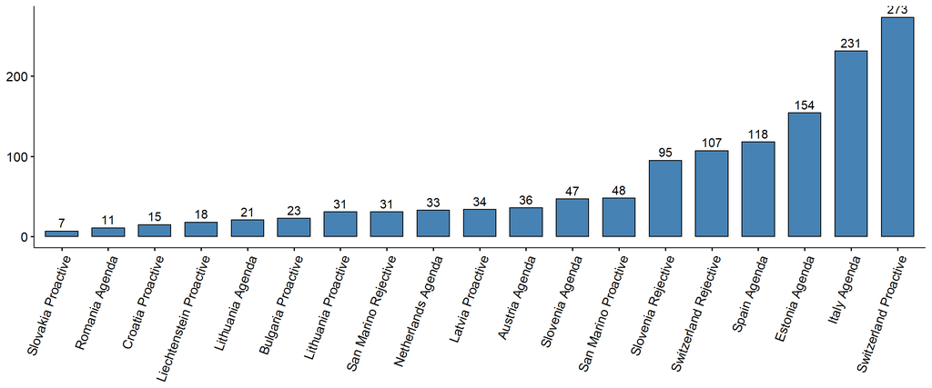

There were 4 countries in the table above that had multiple instruments. These countries are identified in the table below.

### Table: 2.2 Complete country cases with multiple instruments

**CLICK TO SEE RESULTS**

| Country | Type |
| --- | --- |
| Lithuania | Agenda initiative |
| Lithuania | Proactive initiative |
| San Marino | Proactive initiative |
| San Marino | Rejective initiative |
| Slovenia | Agenda initiative |
| Slovenia | Rejective initiative |
| Switzerland | Proactive initiative |
| Switzerland | Rejective initiative |

## 3. Dataset Overview for Complete Cases

This is brief overview of the data structure of the rejection analysis dataset. Since the task is ongoing and there is still more work to be done on consolidating the data, this remains a preliminary glimpse at the data

Presently, the complete dataset has:

- 19 cases
- 15 unique countries
- 1333 observations/events

These numbers will increase significantly when we add Hungary and Finland -and decide how to treat a handful of cases that have “partially complete” data.

### 3.1 The main variables in the dataset

The rejection dataset consists of a compilation of initiative events, which we can think of as “proposals”. The primary unit of analysis is the “Country” X “Instrument” event. Below are what appear to be the main variables from the dataset that we can work with -i.e., not including text variables like title, source, etc.

#### Table: 3.2 List of main variables in the dataset

**CLICK TO SEE RESULTS**

| Variable | Description |
| --- | --- |
| Country | Row repeated for every event |
| Type | Refers to the type of instrument |
| Country/Instrument | Row repeated for every Country X Instrument event |
| Year | There is also a date variable, but for now easier to use the Year |
| Topic | The SG topic coding |
| Referendum_vote | Needs a bit of work; Would be easier to work with a binary, Yes vs No |
| Referendum_outcome | Did the referendum pass; this variable needs further processing |
| Completed | Check description |
| Failed signatures | Check description |
| Admissibility | Check description |
| Outcome | The outcome variable |

We don’t need to collect additional variables at the Country level for this dataset. Additional variables, e.g. whether it’s a small or big country, whether it has a long list of substantive prohibitions or it allows for digital signatures, can all be constructed separately to this dataset.

In the two tables below we can get an idea of (i) the number of observations and (ii) how this breaks down in terms of countries per instrument. The second is more important in terms of structuring how to pursue the analysis.

### Table: 3.3 Summary of Instruments

**CLICK TO SEE RESULTS**

| Type | n |
| --- | --- |
| Agenda initiative | 651 |
| Proactive initiative | 449 |
| Rejective initiative | 233 |

### Table: 3.4 Summary of Instrument with number of countries

**CLICK TO SEE RESULTS**

| Type | N_Countries |
| --- | --- |
| Agenda initiative | 8 |
| Proactive initiative | 8 |
| Rejective initiative | 3 |

### Overall summary of complete data countries

Based on the numbers and the need to compare like with like, it is probably best to analyse the instruments separately to get an idea of the data, at least in the initial stages. In fact it is probably more useful to analyse each “Country X Instrument” separately. This is what is done below, beginning with the Agenda Initiative.

## 4. The Agenda initiative

We begin by analysing the eight countries separately. This allows us to get a better handle of the data across the various categories of interest.

#### Table: 4.0 List of Agenda Initiative Countries

**CLICK TO SEE RESULTS**

| Country | n | Percent |
| --- | --- | --- |
| Austria | 36 | 5.5 |
| Estonia | 154 | 23.7 |
| Italy | 231 | 35.5 |
| Lithuania | 21 | 3.2 |
| Netherlands | 33 | 5.1 |
| Romania | 11 | 1.7 |
| Slovenia | 47 | 7.2 |
| Spain | 118 | 18.1 |

## 4.1 Austria

Austria has a total of 36 AI’s between 1991 and 2020.

#### Table: 4.1.1. Distribution of topics

**CLICK TO SEE RESULTS**

| Topic | n | Percent |
| --- | --- | --- |
| Foreign affairs | 13 | 36.1 |
| Interior Policies | 9 | 25.0 |
| Health | 4 | 11.1 |
| Political / Electoral System | 3 | 8.3 |
| Economy | 2 | 5.6 |
| Education | 2 | 5.6 |
| Environment | 2 | 5.6 |
| Media | 1 | 2.8 |

#### Table: 4.1.2 Outcomes

**CLICK TO SEE RESULTS**

| Outcome | n | Percent |
| --- | --- | --- |
| PreAdmissibile_SuccPostSignature | 28 | 77.8 |
| PreAdmissible_FailedPostSignature | 8 | 22.2 |

#### Table: 4.1.3 Completed

**CLICK TO SEE RESULTS**

| Completed | n | Percent |
| --- | --- | --- |
| Yes | 28 | 77.8 |
| No | 8 | 22.2 |

#### Table: 4.1.4 Failed Signatures

**CLICK TO SEE RESULTS**

| Failed_sig | n | Percent |
| --- | --- | --- |
| No | 28 | 77.8 |
| Yes | 8 | 22.2 |

#### Table: 4.1.5 Admissibility

**CLICK TO SEE RESULTS**

| Admissible | n | Percent |
| --- | --- | --- |
| Yes | 36 | 100 |

## 4.2 Estonia

Estonia has a total of 154 AI’s between 2014 and 2020.

#### Table: 4.2.1. Distribution of topics

**CLICK TO SEE RESULTS**

| Topic | n | Percent |
| --- | --- | --- |
| Interior Policies | 67 | 43.5 |
| Labour & Social | 18 | 11.7 |
| Economy | 17 | 11.0 |
| Political / Electoral System | 14 | 9.1 |
| Education | 10 | 6.5 |
| Health | 10 | 6.5 |
| Environment | 8 | 5.2 |
| Foreign affairs | 7 | 4.5 |
| Moral & Ethics | 2 | 1.3 |
| Media | 1 | 0.6 |

#### Table: 4.2.2 Outcomes

**CLICK TO SEE RESULTS**

| Outcome | n | Percent |
| --- | --- | --- |
| FailedPreSignature | 85 | 55.2 |
| PostAdmissible | 69 | 44.8 |

#### Table: 4.2.3 Completed

**CLICK TO SEE RESULTS**

| Completed | n | Percent |
| --- | --- | --- |
| No | 85 | 55.2 |
| Yes | 69 | 44.8 |

#### Table: 4.2.4 Failed Signatures

**CLICK TO SEE RESULTS**

| Failed_sig | n | Percent |
| --- | --- | --- |
| Yes | 85 | 55.2 |
| No | 69 | 44.8 |

#### Table: 4.2.5 Admissibility

**CLICK TO SEE RESULTS**

| Admissible | n | Percent |
| --- | --- | --- |
| Undecided | 85 | 55.2 |
| Yes | 69 | 44.8 |

## 4.3 Italy

Italy Date variable needs to be fixed.

#### Table: 4.3.1. Distribution of topics

**CLICK TO SEE RESULTS**

| Topic | n | Percent |
| --- | --- | --- |
| Interior Policies | 67 | 29.0 |
| Labour & Social | 48 | 20.8 |
| Political / Electoral System | 41 | 17.7 |
| Economy | 22 | 9.5 |
| Education | 18 | 7.8 |
| Health | 15 | 6.5 |
| Environment | 8 | 3.5 |
| State formation | 7 | 3.0 |
| Foreign affairs | 3 | 1.3 |
| Moral & Ethics | 2 | 0.9 |

#### Table: 4.3.2 Outcomes

**CLICK TO SEE RESULTS**

| Outcome | n | Percent |
| --- | --- | --- |
| PostAdmissible | 226 | 97.8 |
| FailedPostSignature | 5 | 2.2 |

#### Table: 4.3.3 Completed

**CLICK TO SEE RESULTS**

| Completed | n | Percent |
| --- | --- | --- |
| Yes | 226 | 97.8 |
| No | 5 | 2.2 |

#### Table: 4.3.4 Failed Signatures

**CLICK TO SEE RESULTS**

| Failed_sig | n | Percent |
| --- | --- | --- |
| No | 226 | 97.8 |
| Yes | 5 | 2.2 |

#### Table: 4.3.5 Admissibility

**CLICK TO SEE RESULTS**

| Admissible | n | Percent |
| --- | --- | --- |
| Yes | 226 | 97.8 |
| Undecided | 5 | 2.2 |

## 4.4 Lithuania

Lithuania has a total of 21 AI’s between 2000 and 2016.

#### Table: 4.4.1. Distribution of topics

**CLICK TO SEE RESULTS**

| Topic | n | Percent |
| --- | --- | --- |
| Economy | 8 | 40 |
| Environment | 3 | 15 |
| Interior Policies | 3 | 15 |
| Education | 2 | 10 |
| Health | 1 | 5 |
| Labour & Social | 1 | 5 |
| Moral & Ethics | 1 | 5 |
| Political / Electoral System | 1 | 5 |

#### Table: 4.4.2 Outcomes

**CLICK TO SEE RESULTS**

| Outcome | n | Percent |
| --- | --- | --- |
| PreAdmissible_FailedPostSignature | 9 | 45 |
| SuccPreSignature_NA | 6 | 30 |
| SuccPostSignature_NA | 5 | 25 |

#### Table: 4.4.3 Completed

**CLICK TO SEE RESULTS**

| Completed | n | Percent |
| --- | --- | --- |
| No | 9 | 100 |

#### Table: 4.4.4 Failed Signatures

**CLICK TO SEE RESULTS**

| Failed_sig | n | Percent |
| --- | --- | --- |
| Yes | 9 | 60 |
| No | 6 | 40 |

#### Table: 4.4.5 Admissibility

**CLICK TO SEE RESULTS**

| Admissible | n | Percent |
| --- | --- | --- |
| Yes | 9 | 100 |

## 4.5 Netherlands

Netherlands has a total of 33 AI’s between 2007 and 2020.

#### Table: 4.5.1. Distribution of topics

**CLICK TO SEE RESULTS**

| Topic | n | Percent |
| --- | --- | --- |
| Health | 8 | 24.2 |
| Moral & Ethics | 7 | 21.2 |
| Interior Policies | 5 | 15.2 |
| Labour & Social | 4 | 12.1 |
| Foreign affairs | 3 | 9.1 |
| Economy | 2 | 6.1 |
| Education | 2 | 6.1 |
| Environment | 1 | 3.0 |
| Political / Electoral System | 1 | 3.0 |

#### Table: 4.5.2 Outcomes

**CLICK TO SEE RESULTS**

| Outcome | n | Percent |
| --- | --- | --- |
| PostSig_Admissible | 20 | 60.6 |
| SuccPostSignature_Inadmissible | 10 | 30.3 |
| FailedPostSignature_Inadmissible | 2 | 6.1 |
| ProcError | 1 | 3.0 |

#### Table: 4.5.3 Completed

**CLICK TO SEE RESULTS**

| Completed | n | Percent |
| --- | --- | --- |
| Yes | 20 | 60.6 |
| No | 13 | 39.4 |

#### Table: 4.5.4 Failed Signatures

**CLICK TO SEE RESULTS**

| Failed_sig | n | Percent |
| --- | --- | --- |
| No | 31 | 93.9 |
| Yes | 2 | 6.1 |

#### Table: 4.5.5 Admissibility

**CLICK TO SEE RESULTS**

| Admissible | n | Percent |
| --- | --- | --- |
| Yes | 20 | 62.5 |
| No | 12 | 37.5 |

## 4.6 Romania

Romania Date variable is missing or needs to be fixed.

#### Table: 4.6.1. Distribution of topics

**CLICK TO SEE RESULTS**

| Topic | n | Percent |
| --- | --- | --- |
| Education | 3 | 27.3 |
| Constitution | 2 | 18.2 |
| Labour & Social | 2 | 18.2 |
| Political / Electoral System | 2 | 18.2 |
| Health | 1 | 9.1 |
| Interior Policies | 1 | 9.1 |

#### Table: 4.6.2 Outcomes

**CLICK TO SEE RESULTS**

| Outcome | n | Percent |
| --- | --- | --- |
| PostAdmissible | 8 | 72.7 |
| FailedPreSignature | 2 | 18.2 |
| PostInadmissible | 1 | 9.1 |

#### Table: 4.6.3 Completed

**CLICK TO SEE RESULTS**

| Completed | n | Percent |
| --- | --- | --- |
| Yes | 8 | 72.7 |
| No | 3 | 27.3 |

#### Table: 4.6.4 Failed Signatures

**CLICK TO SEE RESULTS**

| Failed_sig | n | Percent |
| --- | --- | --- |
| No | 9 | 81.8 |
| Yes | 2 | 18.2 |

#### Table: 4.6.5 Admissibility

**CLICK TO SEE RESULTS**

| Admissible | n | Percent |
| --- | --- | --- |
| Yes | 8 | 72.7 |
| Undecided | 2 | 18.2 |
| No | 1 | 9.1 |

## 4.7 Slovenia

Slovenia Date variable is missing or needs to be fixed.

#### Table: 4.7.1. Distribution of topics

**CLICK TO SEE RESULTS**

| Topic | n | Percent |
| --- | --- | --- |
| Economy | 11 | 26.2 |
| Interior Policies | 10 | 23.8 |
| Health | 6 | 14.3 |
| Political / Electoral System | 5 | 11.9 |
| Labour & Social | 4 | 9.5 |
| Education | 3 | 7.1 |
| Constitution | 1 | 2.4 |
| Environment | 1 | 2.4 |
| Moral & Ethics | 1 | 2.4 |

#### Table: 4.7.2 Outcomes

**CLICK TO SEE RESULTS**

| Outcome | n | Percent |
| --- | --- | --- |
| PreAdmissibile_SuccPostSignature | 26 | 57.8 |
| PreAdmissible_FailedPostSignature | 8 | 17.8 |
| PreInadmissible | 5 | 11.1 |
| FailedPreSignature | 2 | 4.4 |
| PreSignature_Withdrawn | 1 | 2.2 |
| ProcError | 1 | 2.2 |
| Withdrawn | 1 | 2.2 |
| withdrawn_NA | 1 | 2.2 |

#### Table: 4.7.3 Completed

**CLICK TO SEE RESULTS**

| Completed | n | Percent |
| --- | --- | --- |
| Yes | 26 | 57.8 |
| No | 19 | 42.2 |

#### Table: 4.7.4 Failed Signatures

**CLICK TO SEE RESULTS**

| Failed_sig | n | Percent |
| --- | --- | --- |
| No | 35 | 77.8 |
| Yes | 10 | 22.2 |

#### Table: 4.7.5 Admissibility

**CLICK TO SEE RESULTS**

| Admissible | n | Percent |
| --- | --- | --- |
| Yes | 34 | 81.0 |
| No | 5 | 11.9 |
| Undecided | 3 | 7.1 |

## 4.8 Spain

Spain has a total of 118 AI’s between 1990 and 2020.

#### Table: 4.8.1. Distribution of topics

**CLICK TO SEE RESULTS**

| Topic | n | Percent |
| --- | --- | --- |
| Interior Policies | 52 | 44.1 |
| Labour & Social | 32 | 27.1 |
| Economy | 11 | 9.3 |
| Political / Electoral System | 7 | 5.9 |
| Health | 5 | 4.2 |
| Moral & Ethics | 5 | 4.2 |
| Environment | 3 | 2.5 |
| Education | 2 | 1.7 |
| Constitution | 1 | 0.8 |

#### Table: 4.8.2 Outcomes

**CLICK TO SEE RESULTS**

| Outcome | n | Percent |
| --- | --- | --- |
| PreAdmissible_FailedPostSignature | 48 | 41.0 |
| PreInadmissible | 34 | 29.1 |
| PreAdmissibile_SuccPostSignature | 17 | 14.5 |
| PostInadmissible | 9 | 7.7 |
| PreAdmissible_Withdrawn | 4 | 3.4 |
| PostAdmissible | 2 | 1.7 |
| Other | 1 | 0.9 |
| Withdrawn | 1 | 0.9 |
| withdrawn_NA | 1 | 0.9 |

#### Table: 4.8.3 Completed

**CLICK TO SEE RESULTS**

| Completed | n | Percent |
| --- | --- | --- |
| No | 98 | 83.8 |
| Yes | 19 | 16.2 |

#### Table: 4.8.4 Failed Signatures

**CLICK TO SEE RESULTS**

| Failed_sig | n | Percent |
| --- | --- | --- |
| No | 69 | 59 |
| Yes | 48 | 41 |

#### Table: 4.8.5 Admissibility

**CLICK TO SEE RESULTS**

| Admissible | n | Percent |
| --- | --- | --- |
| Yes | 71 | 62.3 |
| No | 43 | 37.7 |

## 5. The Proactive Initiative

We analyse the eight countries separately. This allows us to get a better handle of the data across the various categories of interest.

#### Table: 5.0 List of Proactive Initiative Countries

**CLICK TO SEE RESULTS**

| Country | n | Percent |
| --- | --- | --- |
| Bulgaria | 23 | 5.1 |
| Croatia | 15 | 3.3 |
| Latvia | 34 | 7.6 |
| Liechtenstein | 18 | 4.0 |
| Lithuania | 31 | 6.9 |
| San Marino | 48 | 10.7 |
| Slovakia | 7 | 1.6 |
| Switzerland | 273 | 60.8 |

## 5.1 Bulgaria

Bulgaria has a total of 23 PI’s between 2010 and 2020.

#### Table: 5.1.1. Distribution of topics

**CLICK TO SEE RESULTS**

| Topic | n | Percent |
| --- | --- | --- |
| Mulitple topics | 8 | 34.8 |
| Political / Electoral System | 5 | 21.7 |
| Foreign affairs | 4 | 17.4 |
| Economy | 2 | 8.7 |
| Interior Policies | 2 | 8.7 |
| Environment | 1 | 4.3 |
| Health | 1 | 4.3 |

#### Table: 5.1.2 Outcomes

**CLICK TO SEE RESULTS**

| Outcome | n | Percent |
| --- | --- | --- |
| ProcError | 6 | 35.3 |
| FailedPreSignature | 3 | 17.6 |
| FailedPostSignature | 2 | 11.8 |
| PostAdmissible | 2 | 11.8 |
| SuccPostSignature_NA | 2 | 11.8 |
| PostInadmissible | 1 | 5.9 |
| Withdrawn | 1 | 5.9 |

#### Table: 5.1.3 Completed

**CLICK TO SEE RESULTS**

| Completed | n | Percent |
| --- | --- | --- |
| No | 13 | 86.7 |
| Yes | 2 | 13.3 |

#### Table: 5.1.4 Failed Signatures

**CLICK TO SEE RESULTS**

| Failed_sig | n | Percent |
| --- | --- | --- |
| No | 10 | 66.7 |
| Yes | 5 | 33.3 |

#### Table: 5.1.5 Referendum Vote

**CLICK TO SEE RESULTS**

| Referendum_vote | n | Percent |
| --- | --- | --- |
| no | 21 | 91.3 |
| yes | 2 | 8.7 |

#### Table: 5.1.6 Referendum Outcome

**CLICK TO SEE RESULTS**

| Referendum_outcome | n | Percent |
| --- | --- | --- |
| failed | 2 | 100 |

#### Table: 5.1.7 Admissibility

**CLICK TO SEE RESULTS**

| Admissible | n | Percent |
| --- | --- | --- |
| Undecided | 5 | 62.5 |
| Yes | 2 | 25.0 |
| No | 1 | 12.5 |

## 5.2 Croatia

Croatia has a total of 15 PI’s between 2007 and 2020.

#### Table: 5.2.1. Distribution of topics

**CLICK TO SEE RESULTS**

| Topic | n | Percent |
| --- | --- | --- |
| Political / Electoral System | 4 | 26.7 |
| Foreign affairs | 3 | 20.0 |
| Interior Policies | 2 | 13.3 |
| Labour & Social | 2 | 13.3 |
| Moral & Ethics | 2 | 13.3 |
| Economy | 1 | 6.7 |
| Mulitple topics | 1 | 6.7 |

#### Table: 5.2.2 Outcomes

**CLICK TO SEE RESULTS**

| Outcome | n | Percent |
| --- | --- | --- |
| FailedPreSignature | 7 | 46.7 |
| PostInadmissible | 5 | 33.3 |
| FailedPostSignature | 2 | 13.3 |
| PostAdmissible | 1 | 6.7 |

#### Table: 5.2.3 Completed

**CLICK TO SEE RESULTS**

| Completed | n | Percent |
| --- | --- | --- |
| No | 14 | 93.3 |
| Yes | 1 | 6.7 |

#### Table: 5.2.4 Failed Signatures

**CLICK TO SEE RESULTS**

| Failed_sig | n | Percent |
| --- | --- | --- |
| Yes | 9 | 60 |
| No | 6 | 40 |

#### Table: 5.2.5 Referendum Vote

**CLICK TO SEE RESULTS**

| Referendum_vote | n | Percent |
| --- | --- | --- |
| no | 14 | 93.3 |
| yes | 1 | 6.7 |

#### Table: 5.2.6 Referendum Outcome

**CLICK TO SEE RESULTS**

| Referendum_outcome | n | Percent |
| --- | --- | --- |
| succeeded | 1 | 100 |

#### Table: 5.2.7 Admissibility

**CLICK TO SEE RESULTS**

| Admissible | n | Percent |
| --- | --- | --- |
| Undecided | 9 | 60.0 |
| No | 5 | 33.3 |
| Yes | 1 | 6.7 |

## 5.3 Latvia

Latvia has a total of 34 PI’s between 2012 and 2020.

#### Table: 5.3.1. Distribution of topics

**CLICK TO SEE RESULTS**

| Topic | n | Percent |
| --- | --- | --- |
| Political / Electoral System | 19 | 55.9 |
| Economy | 6 | 17.6 |
| Constitution | 4 | 11.8 |
| Interior Policies | 3 | 8.8 |
| Education | 2 | 5.9 |

#### Table: 5.3.2 Outcomes

**CLICK TO SEE RESULTS**

| Outcome | n | Percent |
| --- | --- | --- |
| PreAdmissible_FailedPostSignature | 21 | 61.8 |
| PreInadmissible | 13 | 38.2 |

#### Table: 5.3.3 Completed

**CLICK TO SEE RESULTS**

| Completed | n | Percent |
| --- | --- | --- |
| No | 34 | 100 |

#### Table: 5.3.4 Failed Signatures

**CLICK TO SEE RESULTS**

| Failed_sig | n | Percent |
| --- | --- | --- |
| Yes | 21 | 61.8 |
| No | 13 | 38.2 |

#### Table: 5.3.5 Referendum Vote

**CLICK TO SEE RESULTS**

| Referendum_vote | n | Percent |
| --- | --- | --- |
| no | 34 | 100 |

#### Table: 5.3.6 Referendum Outcome

**CLICK TO SEE RESULTS**

| Referendum_outcome | n | Percent |
| --- | --- | --- |

#### Table: 5.3.7 Admissibility

**CLICK TO SEE RESULTS**

| Admissible | n | Percent |
| --- | --- | --- |
| Yes | 21 | 61.8 |
| No | 13 | 38.2 |

## 5.4 Liechtenstein

Liechtenstein has a total of 18 PI’s between 1991 and 2019.

#### Table: 5.4.1. Distribution of topics

**CLICK TO SEE RESULTS**

| Topic | n | Percent |
| --- | --- | --- |
| Political / Electoral System | 5 | 27.8 |
| Moral & Ethics | 4 | 22.2 |
| Health | 3 | 16.7 |
| Labour & Social | 3 | 16.7 |
| Education | 1 | 5.6 |
| Environment | 1 | 5.6 |
| Interior Policies | 1 | 5.6 |

#### Table: 5.4.2 Outcomes

**CLICK TO SEE RESULTS**

| Outcome | n | Percent |
| --- | --- | --- |
| PreAdmissibile_SuccPostSignature | 16 | 88.9 |
| Other | 1 | 5.6 |
| PreInadmissible | 1 | 5.6 |

#### Table: 5.4.3 Completed

**CLICK TO SEE RESULTS**

| Completed | n | Percent |
| --- | --- | --- |
| Yes | 16 | 88.9 |
| No | 2 | 11.1 |

#### Table: 5.4.4 Failed Signatures

**CLICK TO SEE RESULTS**

| Failed_sig | n | Percent |
| --- | --- | --- |
| No | 18 | 100 |

#### Table: 5.4.5 Referendum Vote

**CLICK TO SEE RESULTS**

| Referendum_vote | n | Percent |
| --- | --- | --- |
| yes | 16 | 88.9 |
| no | 2 | 11.1 |

#### Table: 5.4.6 Referendum Outcome

**CLICK TO SEE RESULTS**

| Referendum_outcome | n | Percent |
| --- | --- | --- |
| failed | 13 | 76.5 |
| succeeded | 3 | 17.6 |
| Other | 1 | 5.9 |

#### Table: 5.4.7 Admissibility

**CLICK TO SEE RESULTS**

| Admissible | n | Percent |
| --- | --- | --- |
| Yes | 16 | 94.1 |
| No | 1 | 5.9 |

## 5.5 Lithuania

#### Table: 5.5.1. Distribution of topics

**CLICK TO SEE RESULTS**

| Topic | n | Percent |
| --- | --- | --- |
| Political / Electoral System | 18 | 58.1 |
| Mulitple topics | 4 | 12.9 |
| Interior Policies | 3 | 9.7 |
| Economy | 2 | 6.5 |
| Environment | 2 | 6.5 |
| Foreign affairs | 1 | 3.2 |
| Labour & Social | 1 | 3.2 |

#### Table: 5.5.2 Outcomes

**CLICK TO SEE RESULTS**

| Outcome | n | Percent |
| --- | --- | --- |
| PreAdmissible_FailedPostSignature | 20 | 74.1 |
| PreAdmissibile_SuccPostSignature | 4 | 14.8 |
| PreAdmissible_ProcError | 2 | 7.4 |
| PreInadmissible | 1 | 3.7 |

#### Table: 5.5.3 Completed

**CLICK TO SEE RESULTS**

| Completed | n | Percent |
| --- | --- | --- |
| No | 23 | 85.2 |
| Yes | 4 | 14.8 |

#### Table: 5.5.4 Failed Signatures

**CLICK TO SEE RESULTS**

| Failed_sig | n | Percent |
| --- | --- | --- |
| Yes | 20 | 74.1 |
| No | 7 | 25.9 |

#### Table: 5.5.5 Referendum Vote

**CLICK TO SEE RESULTS**

| Referendum_vote | n | Percent |
| --- | --- | --- |
| no | 27 | 90 |
| yes | 3 | 10 |

#### Table: 5.5.6 Referendum Outcome

**CLICK TO SEE RESULTS**

| Referendum_outcome | n | Percent |
| --- | --- | --- |
| failed | 3 | 100 |

#### Table: 5.5.7 Admissibility

**CLICK TO SEE RESULTS**

| Admissible | n | Percent |
| --- | --- | --- |
| Yes | 26 | 96.3 |
| No | 1 | 3.7 |

## 5.6 San Marino

San Marino has a total of 48 PI’s between 1996 and 2018.

#### Table: 5.6.1. Distribution of topics

**CLICK TO SEE RESULTS**

| Topic | n | Percent |
| --- | --- | --- |
| Political / Electoral System | 22 | 45.8 |
| Economy | 9 | 18.8 |
| Interior Policies | 9 | 18.8 |
| Foreign affairs | 3 | 6.2 |
| Environment | 2 | 4.2 |
| Labour & Social | 2 | 4.2 |
| Mulitple topics | 1 | 2.1 |

#### Table: 5.6.2 Outcomes

**CLICK TO SEE RESULTS**

| Outcome | n | Percent |
| --- | --- | --- |
| PostSig_Admissible | 22 | 45.8 |
| SuccPostSignature_Inadmissible | 17 | 35.4 |
| inadmissible_NA | 7 | 14.6 |
| Other | 1 | 2.1 |
| SuccPreSignature_Inadmissible | 1 | 2.1 |

#### Table: 5.6.3 Completed

**CLICK TO SEE RESULTS**

| Completed | n | Percent |
| --- | --- | --- |
| No | 26 | 54.2 |
| Yes | 22 | 45.8 |

#### Table: 5.6.4 Failed Signatures

**CLICK TO SEE RESULTS**

| Failed_sig | n | Percent |
| --- | --- | --- |
| No | 41 | 100 |

#### Table: 5.6.5 Referendum Vote

**CLICK TO SEE RESULTS**

| Referendum_vote | n | Percent |
| --- | --- | --- |
| no | 27 | 64.3 |
| yes | 15 | 35.7 |

#### Table: 5.6.6 Referendum Outcome

**CLICK TO SEE RESULTS**

| Referendum_outcome | n | Percent |
| --- | --- | --- |
| failed | 9 | 60 |
| succeeded | 6 | 40 |

#### Table: 5.6.7 Admissibility

**CLICK TO SEE RESULTS**

| Admissible | n | Percent |
| --- | --- | --- |
| No | 25 | 53.2 |
| Yes | 22 | 46.8 |

## 5.7 Slovakia

Slovakia has a total of 7 PI’s between 1997 and 2014.

#### Table: 5.7.1. Distribution of topics

**CLICK TO SEE RESULTS**

| Topic | n | Percent |
| --- | --- | --- |
| Political / Electoral System | 4 | 57.1 |
| Economy | 1 | 14.3 |
| Moral & Ethics | 1 | 14.3 |
| Mulitple topics | 1 | 14.3 |

#### Table: 5.7.2 Outcomes

**CLICK TO SEE RESULTS**

| Outcome | n | Percent |
| --- | --- | --- |
| PostAdmissible | 6 | 85.7 |
| PostInadmissible | 1 | 14.3 |

#### Table: 5.7.3 Completed

**CLICK TO SEE RESULTS**

| Completed | n | Percent |
| --- | --- | --- |
| Yes | 6 | 85.7 |
| No | 1 | 14.3 |

#### Table: 5.7.4 Failed Signatures

**CLICK TO SEE RESULTS**

| Failed_sig | n | Percent |
| --- | --- | --- |
| No | 7 | 100 |

#### Table: 5.7.5 Referendum Vote

**CLICK TO SEE RESULTS**

| Referendum_vote | n | Percent |
| --- | --- | --- |
| yes | 6 | 85.7 |
| no | 1 | 14.3 |

#### Table: 5.7.6 Referendum Outcome

**CLICK TO SEE RESULTS**

| Referendum_outcome | n | Percent |
| --- | --- | --- |
| failed | 6 | 100 |

#### Table: 5.7.7 Admissibility

**CLICK TO SEE RESULTS**

| Admissible | n | Percent |
| --- | --- | --- |
| Yes | 6 | 85.7 |
| No | 1 | 14.3 |

## 5.8 Switzerland

Switzerland has a total of 273 PI’s between 1990 and 2020.

#### Table: 5.8.1. Distribution of topics

**CLICK TO SEE RESULTS**

| Topic | n | Percent |
| --- | --- | --- |
| Interior Policies | 71 | 26.0 |
| Economy | 45 | 16.5 |
| Labour & Social | 35 | 12.8 |
| Moral & Ethics | 31 | 11.4 |
| Environment | 28 | 10.3 |
| Health | 23 | 8.4 |
| Foreign affairs | 14 | 5.1 |
| Political / Electoral System | 12 | 4.4 |
| Education | 7 | 2.6 |
| Mulitple topics | 3 | 1.1 |
| Constitution | 2 | 0.7 |
| Media | 2 | 0.7 |

#### Table: 5.8.2 Outcomes

**CLICK TO SEE RESULTS**

| Outcome | n | Percent |
| --- | --- | --- |
| PostAdmissible | 119 | 43.6 |
| FailedPostSignature | 107 | 39.2 |
| PostAdmissible_Withdrawn | 42 | 15.4 |
| SuccPostSignature_NA | 3 | 1.1 |
| PostInadmissible | 2 | 0.7 |

#### Table: 5.8.3 Completed

**CLICK TO SEE RESULTS**

| Completed | n | Percent |
| --- | --- | --- |
| No | 151 | 55.9 |
| Yes | 119 | 44.1 |

#### Table: 5.8.4 Failed Signatures

**CLICK TO SEE RESULTS**

| Failed_sig | n | Percent |
| --- | --- | --- |
| No | 163 | 60.4 |
| Yes | 107 | 39.6 |

#### Table: 5.8.5 Referendum Vote

**CLICK TO SEE RESULTS**

| Referendum_vote | n | Percent |
| --- | --- | --- |
| no | 141 | 51.6 |
| yes | 125 | 45.8 |
| not yet | 7 | 2.6 |

**CLICK TO SEE RESULTS**

#### Table: 5.8.7 Admissibility

**CLICK TO SEE RESULTS**

| Admissible | n | Percent |
| --- | --- | --- |
| Yes | 161 | 59.6 |
| Undecided | 107 | 39.6 |
| No | 2 | 0.7 |

## 6. The Rejective Initiative

We analyse the three countries separately. This allows us to get a better handle of the data across the various categories of interest.

**CLICK TO SEE RESULTS**

| Country | n | Percent |
| --- | --- | --- |
| San Marino | 31 | 13.3 |
| Slovenia | 95 | 40.8 |
| Switzerland | 107 | 45.9 |

## 6.1 San Marino

#### Table: 6.1.1. Distribution of topics

**CLICK TO SEE RESULTS**

| Topic | n | Percent |
| --- | --- | --- |
| Political / Electoral System | 13 | 41.9 |
| Labour & Social | 8 | 25.8 |
| Economy | 3 | 9.7 |
| Interior Policies | 3 | 9.7 |
| Education | 2 | 6.5 |
| Environment | 1 | 3.2 |
| Moral & Ethics | 1 | 3.2 |

#### Table: 6.1.2 Outcomes

**CLICK TO SEE RESULTS**

| Outcome | n | Percent |
| --- | --- | --- |
| PostSig_Admissible | 11 | 35.5 |
| SuccPostSignature_Inadmissible | 6 | 19.4 |
| PreInadmissible | 5 | 16.1 |
| FailedPostSignature | 3 | 9.7 |
| inadmissible_NA | 2 | 6.5 |
| Other | 2 | 6.5 |
| admissible_NA | 1 | 3.2 |
| SuccPreSignature_Inadmissible | 1 | 3.2 |

#### Table: 6.1.3 Completed

**CLICK TO SEE RESULTS**

| Completed | n | Percent |
| --- | --- | --- |
| No | 19 | 63.3 |
| Yes | 11 | 36.7 |

#### Table: 6.1.4 Failed Signatures

**CLICK TO SEE RESULTS**

| Failed_sig | n | Percent |
| --- | --- | --- |
| No | 25 | 89.3 |
| Yes | 3 | 10.7 |

#### Table: 6.1.5 Referendum Vote

**CLICK TO SEE RESULTS**

| Referendum_vote | n | Percent |
| --- | --- | --- |
| no | 19 | 70.4 |
| yes | 8 | 29.6 |

#### Table: 6.1.6 Referendum Outcome

**CLICK TO SEE RESULTS**

| Referendum_outcome | n | Percent |
| --- | --- | --- |
| succeeded | 5 | 62.5 |
| failed | 3 | 37.5 |

#### Table: 6.1.7 Admissibility

**CLICK TO SEE RESULTS**

| Admissible | n | Percent |
| --- | --- | --- |
| No | 14 | 48.3 |
| Yes | 12 | 41.4 |
| Undecided | 3 | 10.3 |

## 6.2 Slovenia

#### Table: 6.2.1. Distribution of topics

**CLICK TO SEE RESULTS**

| Topic | n | Percent |
| --- | --- | --- |
| Interior Policies | 27 | 29.3 |
| Economy | 25 | 27.2 |
| Political / Electoral System | 12 | 13.0 |
| Foreign affairs | 8 | 8.7 |
| Health | 5 | 5.4 |
| Labour & Social | 5 | 5.4 |
| Moral & Ethics | 4 | 4.3 |
| Environment | 3 | 3.3 |
| Education | 2 | 2.2 |
| Mulitple topics | 1 | 1.1 |

#### Table: 6.2.2 Outcomes

**CLICK TO SEE RESULTS**

| Outcome | n | Percent |
| --- | --- | --- |
| SuccPreSignature_Inadmissible | 21 | 22.1 |
| PreAdmissible_FailedPostSignature | 20 | 21.1 |
| PreInadmissible | 11 | 11.6 |
| PreAdmissibile_SuccPostSignature | 10 | 10.5 |
| PreAdmissible_Withdrawn | 9 | 9.5 |
| inadmissible_NA | 6 | 6.3 |
| Admissible_FailedPreSignature | 4 | 4.2 |
| FailedPreSignature | 4 | 4.2 |
| FailedPreSignature_Inadmissible | 3 | 3.2 |
| PreSignature_Withdrawn | 2 | 2.1 |
| admissible_NA | 1 | 1.1 |
| Other | 1 | 1.1 |
| Post_Signature_Withdrawn | 1 | 1.1 |
| ProcError | 1 | 1.1 |
| Withdrawn | 1 | 1.1 |

#### Table: 6.2.3 Completed

**CLICK TO SEE RESULTS**

| Completed | n | Percent |
| --- | --- | --- |
| No | 84 | 89.4 |
| Yes | 10 | 10.6 |

#### Table: 6.2.4 Failed Signatures

**CLICK TO SEE RESULTS**

| Failed_sig | n | Percent |
| --- | --- | --- |
| No | 57 | 64.8 |
| Yes | 31 | 35.2 |

#### Table: 6.2.5 Referendum Vote

**CLICK TO SEE RESULTS**

| Referendum_vote | n | Percent |
| --- | --- | --- |
| no | 85 | 89.5 |
| yes | 10 | 10.5 |

#### Table: 6.2.6 Referendum Outcome

**CLICK TO SEE RESULTS**

| Referendum_outcome | n | Percent |
| --- | --- | --- |
| succeeded | 7 | 70 |
| failed | 3 | 30 |

#### Table: 6.2.7 Admissibility

**CLICK TO SEE RESULTS**

| Admissible | n | Percent |
| --- | --- | --- |
| Yes | 44 | 47.8 |
| No | 41 | 44.6 |
| Undecided | 7 | 7.6 |

## 6.3 Switzerland

#### Table: 6.3.1. Distribution of topics

**CLICK TO SEE RESULTS**

| Topic | n | Percent |
| --- | --- | --- |
| Interior Policies | 38 | 35.5 |
| Labour & Social | 22 | 20.6 |
| Economy | 15 | 14.0 |
| Foreign affairs | 15 | 14.0 |
| Environment | 7 | 6.5 |
| Moral & Ethics | 7 | 6.5 |
| Education | 1 | 0.9 |
| Health | 1 | 0.9 |
| Media | 1 | 0.9 |

#### Table: 6.3.2 Outcomes

**CLICK TO SEE RESULTS**

| Outcome | n | Percent |
| --- | --- | --- |
| AllAdmissible | 93 | 86.9 |
| AllAdmissible_FailedPostSignature | 14 | 13.1 |

#### Table: 6.3.3 Completed

**CLICK TO SEE RESULTS**

| Completed | n | Percent |
| --- | --- | --- |
| Yes | 93 | 86.9 |
| no | 14 | 13.1 |

#### Table: 6.3.4 Failed Signatures

**CLICK TO SEE RESULTS**

| Failed_sig | n | Percent |
| --- | --- | --- |
| No | 93 | 86.9 |
| yes | 14 | 13.1 |

#### Table: 6.3.5 Referendum Vote

**CLICK TO SEE RESULTS**

| Referendum_vote | n | Percent |
| --- | --- | --- |
| yes | 93 | 86.9 |
| no | 14 | 13.1 |

**CLICK TO SEE RESULTS**

#### Table: 6.3.7 Admissibility

**CLICK TO SEE RESULTS**

| Admissible | n | Percent |
| --- | --- | --- |
| Yes | 93 | 86.9 |
| yes | 14 | 13.1 |

## 7. Summaries of Instruments

We can look at the admissibility rates across the instruments.

The main issue here is what to do with the “Undecided” category. Should these be removed altogether? Left in? The choice has a significant affect on the calculation of a rejection rate.

## 7.1 Summary of the Agenda Initiative

#### Table: 7.1 The Agenda Initiative

**CLICK TO SEE RESULTS**

Displaying Percentages

| Country | No | Undecided | Yes |
| --- | --- | --- | --- |
| Austria | NA | NA | 100.0 |
| Estonia | NA | 55.2 | 44.8 |
| Italy | NA | 2.2 | 97.8 |
| Lithuania | NA | NA | 100.0 |
| Netherlands | 37.5 | NA | 62.5 |
| Romania | 9.1 | 18.2 | 72.7 |
| Slovenia | 11.9 | 7.1 | 81.0 |
| Spain | 37.7 | NA | 62.3 |

Displaying Frequencies

| Country | No | Undecided | Yes |
| --- | --- | --- | --- |
| Austria | NA | NA | 36 |
| Estonia | NA | 85 | 69 |
| Italy | NA | 5 | 226 |
| Lithuania | NA | NA | 9 |
| Netherlands | 12 | NA | 20 |
| Romania | 1 | 2 | 8 |
| Slovenia | 5 | 3 | 34 |
| Spain | 43 | NA | 71 |

## 7.2 Summary of the Proactive Initiative

#### Table: 7.2 The Proactive Initiative

**CLICK TO SEE RESULTS**

Displaying Percentages

| Country | No | Undecided | Yes |
| --- | --- | --- | --- |
| Bulgaria | 12.5 | 62.5 | 25.0 |
| Croatia | 33.3 | 60.0 | 6.7 |
| Latvia | 38.2 | NA | 61.8 |
| Liechtenstein | 5.9 | NA | 94.1 |
| Lithuania | 3.7 | NA | 96.3 |
| San Marino | 53.2 | NA | 46.8 |
| Slovakia | 14.3 | NA | 85.7 |
| Switzerland | 0.7 | 39.6 | 59.6 |

Displaying Frequencies

| Country | No | Undecided | Yes |
| --- | --- | --- | --- |
| Bulgaria | 1 | 5 | 2 |
| Croatia | 5 | 9 | 1 |
| Latvia | 13 | NA | 21 |
| Liechtenstein | 1 | NA | 16 |
| Lithuania | 1 | NA | 26 |
| San Marino | 25 | NA | 22 |
| Slovakia | 1 | NA | 6 |
| Switzerland | 2 | 107 | 161 |

## 7.3 Summary of the Rejective Initiative

#### Table: 7.3 The Rejective Initiative

**CLICK TO SEE RESULTS**

Displaying Percentages

| Country | No | Undecided | yes | Yes |
| --- | --- | --- | --- | --- |
| San Marino | 48.3 | 10.3 | NA | 41.4 |
| Slovenia | 44.6 | 7.6 | NA | 47.8 |
| Switzerland | NA | NA | 13.1 | 86.9 |

Displaying Frequencies

| Country | No | Undecided | yes | Yes |
| --- | --- | --- | --- | --- |
| San Marino | 14 | 3 | NA | 12 |
| Slovenia | 41 | 7 | NA | 44 |
| Switzerland | NA | NA | 14 | 93 |